Skip to main content

# Getting started

This page takes you from installation to your first results in about ten minutes. No prior knowledge of the package is assumed and basic notions of vibration (mass, stiffness, damping, resonance) are enough.

**TipThe main idea to remember**

Every computation in `StructuralVibration.jl` follows the same four steps:

1. **Model** – describe the structure (`Sdof`, `Beam`, `Plate`, FE matrices…)
2. **Problem** – say *what* you want to compute (free response, forced response, FRF,…)
3. **Solve** – call `solve(prob)` (optionally with a solver, e.g. `solve(prob, Newmark())`)
4. **Post-process** – plot, compare, extract modal parameters, …

Once you have understood this pattern on a single-degree-of-freedom system, the rest of the package follows naturally.

## 1 Installation

```julia
julia> ]
pkg> add StructuralVibration, CairoMakie
```

`CairoMakie.jl` is optional but it activates the plotting functions of the package (`bode_plot`, `stabilization_plot`, …). Any other Makie backend (`GLMakie.jl`, `WGLMakie.jl`) works as well.

```julia
using StructuralVibration, CairoMakie
```

## 2 Step 1 – Define a model

We start with the simplest vibrating system: a mass $m$ attached to a spring and a viscous damper. It is fully described by its mass, its natural frequency $f_0$ and its damping ratio $\xi$.

```julia
m  = 1.     # Mass (kg)
f0 = 10.    # Natural frequency (Hz)
ξ  = 0.02   # Damping ratio (2 %)

sdof = Sdof(m, f0, ξ)
```

## 3 Step 2 – Free response

Let us pull the mass away from its equilibrium position and release it. The *problem* gathers the model, the initial conditions `[x₀, v₀]` and the time vector.

```julia
t  = 0.:1e-3:2.
u0 = [1e-3, 0.]    # Initial displacement (m) and velocity (m/s)

prob_free = SdofFreeTimeProblem(sdof, u0, t)
x_free = solve(prob_free).u
```

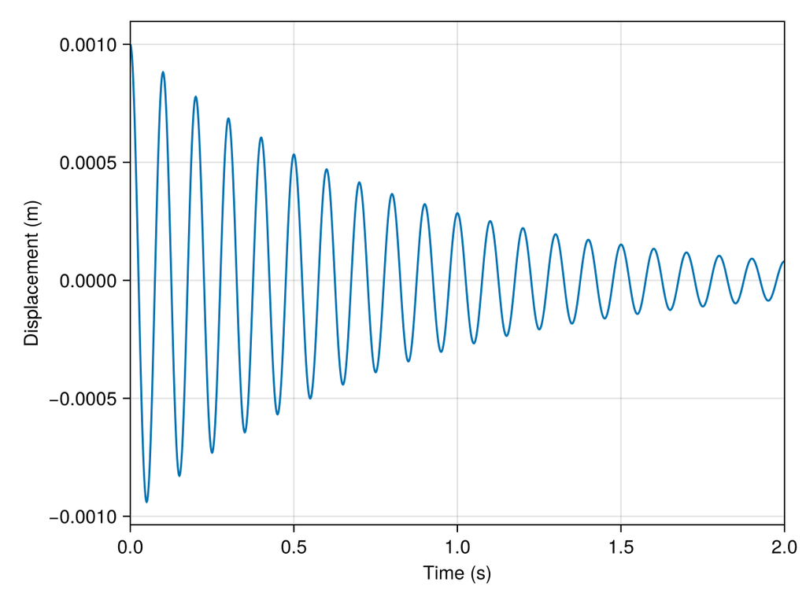

```julia
sv_plot(t, x_free, xlabel = "Time (s)", ylabel = "Displacement (m)")
```

The system oscillates at (almost) $f_0$ = 10 Hz and the amplitude decays because of damping. Try `ξ = 0.` or `ξ = 1.` to see an undamped and a critically damped system.

## 4 Step 3 – Forced response

Now, we excite the mass with a harmonic force $F(t) = F_0 \sin(2\pi f t)$. Only the *problem* changes: the model and the call to `solve` stay the same.

```julia
F0 = 10.   # Force amplitude (N)
f  = 9.5   # Excitation frequency (Hz), close to resonance

prob_harmo = SdofHarmonicTimeProblem(sdof, u0, t, F0, f, :force)
x_harmo = solve(prob_harmo).u
```

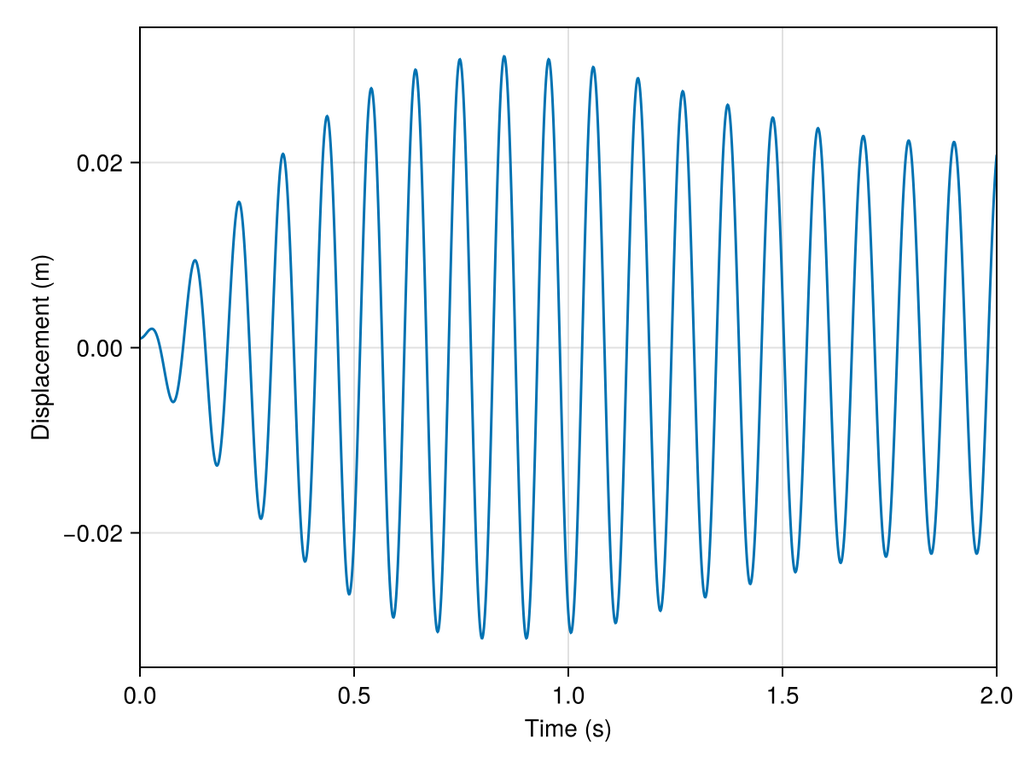

```julia
sv_plot(t, x_harmo, xlabel = "Time (s)", ylabel = "Displacement (m)")
```

The response combines a decaying transient (free response) and a steady-state oscillation at the excitation frequency. Arbitrary excitations (impacts, sweeps, random noise) are handled by `SdofForcedTimeProblem` together with the signals described in Excitation models.

## 5 Step 4 – Frequency Response Function

Rather than computing one response per excitation frequency, we usually characterize a structure by its Frequency Response Function (FRF) $H(f)$, the ratio between the displacement and the force at each frequency.

```julia
freq = 1.:0.05:30.

prob_frf = SdofFRFProblem(sdof, freq)
H = solve(prob_frf).u
```

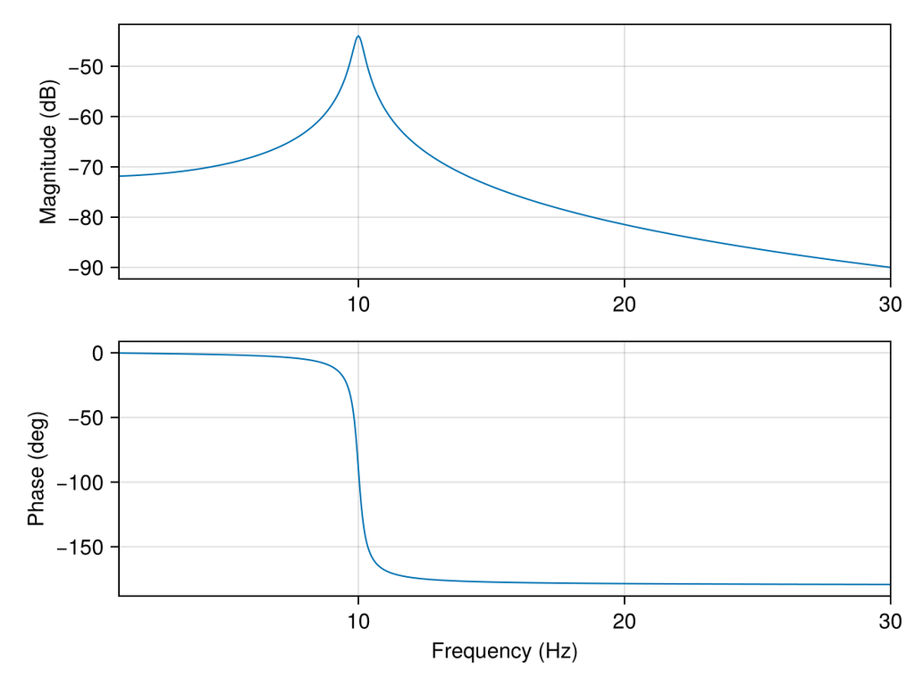

```julia
bode_plot(freq, H, isdeg = true)
```

The resonance peak is located at $f_0$ and its sharpness is governed by $\xi$. The phase shifts by 180° when crossing the resonance.

## 6 Step 5 – Same pattern, real structure

The four steps remain the same for continuous structures. Here, we compute the FRFs of a simply supported steel beam from its modes, add measurement noise, and identify its natural frequencies back, as an experimentalist would.

```julia
# 1. Model - Simply supported beam
L, b, h = 1., 0.03, 0.01
beam = Beam(L, b*h, b*h^3/12, 2.1e11, 7850.)

fmax = 500.
ωn, kn = modefreq(beam, 2fmax)       # Natural frequencies and wavenumbers
xm, xe = [0.2, 0.7], [0.35]          # Measurement and excitation points
ms_m, ms_e = modeshape(beam, kn, xm), modeshape(beam, kn, xe)

# 2. Problem + 3. Solve - Accelerances by modal superposition
freq = 1.:0.25:fmax
ξn = 0.01
prob = ModalFRFProblem(ωn, ξ, freq, ms_m, ms_e)
H = solve(prob, type = :acc, progress = false).u

# 4. Post-process - Noisy "measurement" (SNR = 40 dB) + modal identification
H_meas = agwn(H, 40.)
poles = poles_extraction(EMAProblem(H_meas, freq, type_frf = :acc), 20, LSCF())
fn_id, ξn_id = poles2modal(poles)
```

We computed accelerances (acceleration/force) because this is what an accelerometer and an impact hammer actually measure.

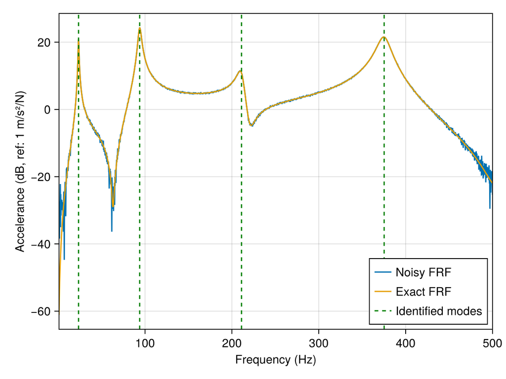

```julia
fig = Figure()
ax = Axis(fig[1, 1], xlabel = "Frequency (Hz)", ylabel = "Accelerance (dB, ref: 1 m/s²/N)")
lines!(ax, freq, to_dB.(H_meas[1, 1, :]), label = "Noisy FRF")
lines!(ax, freq, to_dB.(H[1, 1, :]), label = "Exact FRF")
vlines!(ax, fn_id, color = :green, linestyle = :dash, label = "Identified modes")
xlims!(ax, freq[1], freq[end])
axislegend(ax, position = :rb)
fig
```

```julia
fn_exact = ωn[ωn .≤ 2π*fmax]/2π
println("Exact frequencies (Hz):      ", round.(fn_exact, digits = 2))
println("Identified frequencies (Hz): ", round.(fn_id, digits = 2))
println("Identified damping (%):      ", round.(100ξn_id, digits = 2))
```

```
Exact frequencies (Hz):      [23.45, 93.81, 211.08, 375.25]
Identified frequencies (Hz): [23.45, 93.82, 211.08, 375.27]
Identified damping (%):      [2.0, 1.99, 2.02, 2.0]
```

In twenty lines, we went from a structural model to synthetic measurements and back to modal parameters with a known ground truth. This round trip is what the package is designed for.

## 7 Where to go next?

| I want to… | Go to |
| --- | --- |
| Discover structural dynamics interactively | Apps |
| Build a complete virtual test campaign | From model to virtual measurement |
| Perform an experimental modal analysis | Experimental modal analysis |
| Identify modes from responses only | Operational modal analysis |
| Simulate a FE model in the time domain | Choosing a time integration scheme |
| Estimate the noise level of a signal or denoise it | Noise estimation and denoising |
| Display and animate mode shapes | Visualizing and animating deflection shapes |
| Use my own matrices or measurements | Using your own models and data |
| Look up a function or a type | Models, Solvers, Signal processing |